# 부하 예측을 위한 Neural Network 모델 학습

## 사용 패키지

```python
import pandas as pd
import torch
import torch.nn as nn
import torch.optim as optim
from torch.utils.data import Dataset, DataLoader
from sklearn.model_selection import train_test_split
from sklearn.preprocessing import StandardScaler

import matplotlib.pyplot as plt
from sklearn.metrics import mean_absolute_percentage_error
from tqdm import tqdm

from numpy import NaN, NAN, nan
```

## 데이터 불러오기 및 입출력 값 분리

```python
data = pd.read_csv("Training_data.csv", index_col=0)
features = data.drop(columns=["Time","Generation"])
target = data["Generation"]
```

## sklearn의 train_test_split 함수

`train_test_split` 함수는 scikit-learn 라이브러리에 있는 유용한 도구로, 주어진 데이터를 훈련 세트와 테스트 세트로 분리해줍니다. 이렇게 데이터를 분리하는 이유는 모델을 학습할 때 사용하는 데이터와 모델을 평가할 때 사용하는 데이터를 분리해서 과적합(overfitting)을 방지하기 위함입니다.

### 파라미터 설명

#### 1. test_size

`test_size`는 테스트 세트의 비율이나 크기를 결정합니다.

- **실수(float)**: 0과 1 사이의 값을 입력하면, 해당 비율만큼의 데이터 샘플이 테스트 세트로 할당됩니다. 예를 들어, 0.25는 전체 데이터의 25%를 테스트 세트로 사용하겠다는 의미입니다.
- **정수(int)**: 테스트 세트에 포함될 데이터 샘플의 절대 수를 지정할 수 있습니다. 예를 들어, 100이라는 값을 입력하면 테스트 세트에 100개의 데이터 샘플이 포함됩니다.

#### 2. random_state

`random_state`는 데이터 분할시 사용되는 난수 시드값입니다. 이 값이 설정되면, 함수를 여러 번 호출해도 동일한 데이터 분할이 발생합니다.

- **정수(int)**: 난수 생성기에 제공되는 시드 값입니다.
- **None**: 난수 생성기에 시드 값이 제공되지 않습니다. 이 경우, 매번 호출시마다 다른 데이터 분할이 발생할 수 있습니다.

```python
X_train, X_test, y_train, y_test = train_test_split(features, target, test_size=0.2, random_state=42)
```

## Sclaer?

많은 머신러닝 추정기(estimator)는 특징이 표준 정규 분포와 유사한 형태를 띠도록 요구합니다. 이렇게 가정하는 이유는, 머신러닝 알고리즘의 목적 함수(objective function)의 많은 요소들 (예: SVM의 RBF 커널, 선형 모델의 L1 및 L2 정규화)이 특징이 중심을 기준으로 분포하고 있으며 동일한 크기의 분산을 가지도록 기대하기 때문입니다. 만약 어떤 특징의 분산이 다른 특징들보다 월등히 크다면, 그 특징이 목적 함수를 지배하게 되어 추정기가 다른 특징들로부터 올바르게 학습하지 못할 수 있습니다.

## StandardScaler 함수

`StandardScaler`는 scikit-learn 라이브러리에 있는 전처리(preprocessing) 도구 중 하나입니다. 이 스케일러는 데이터를 표준화(standardization)해줍니다. 표준화는 데이터의 평균을 0으로, 표준편차를 1로 변환하는 과정을 말합니다. 표준화는 다양한 머신러닝 알고리즘에서 모델의 성능을 향상시키는 데 도움이 됩니다.

### 사용 방법

```python
scaler = StandardScaler()
X_train = scaler.fit_transform(X_train)
X_test = scaler.transform(X_test)
```

```python
class TabularDataset(Dataset):
    def __init__(self, X_data, y_data):
        self.X_data = X_data
        self.y_data = y_data

    def __getitem__(self, index):
        return self.X_data[index], self.y_data[index]

    def __len__(self):
        return len(self.X_data)
```

```python
train_dataset = TabularDataset(torch.FloatTensor(X_train), torch.FloatTensor(y_train.to_numpy()))
test_dataset = TabularDataset(torch.FloatTensor(X_test), torch.FloatTensor(y_test.to_numpy()))


train_loader = DataLoader(dataset=train_dataset, batch_size=64)
test_loader = DataLoader(dataset=test_dataset, batch_size=1)
```

## NeuralNet 클래스 설명

`NeuralNet` 클래스는 PyTorch의 `nn.Module`을 상속받아 구현된 신경망 모델입니다. 이 클래스는 입력 데이터에 대해 일련의 연산을 수행하고, 출력을 반환하는 기본적인 신경망 구조를 가지고 있습니다.

### 주요 구성요소

#### 1. `super(NeuralNet, self).__init__()`

- `super()` 함수는 자식 클래스에서 부모 클래스의 메서드를 호출할 때 사용됩니다.
- 여기서는 `NeuralNet` 클래스(자식 클래스)에서 `nn.Module`의 `__init__` 메서드(부모 클래스)를 호출하는 것입니다.
- 이 호출은 신경망 모델의 모든 기본 설정을 초기화하는데 필요합니다.

#### 2. `nn.Linear`

- `nn.Linear`는 선형 레이어(또는 완전 연결 레이어, Fully Connected Layer)를 정의하는 PyTorch의 클래스입니다.
- 각 `nn.Linear` 인스턴스는 입력과 출력의 차원 수에 따라 가중치와 편향을 포함합니다.
- 예: `self.layer_1 = nn.Linear(input_dim, 128)`는 `input_dim` 크기의 입력을 받아 128 크기의 출력을 생성하는 레이어를 정의합니다.

#### 3. `forward`

- `forward` 함수는 `nn.Module` 클래스의 메서드로, 모델이 어떻게 입력 데이터를 처리하여 출력을 반환하는지를 정의합니다.
- 실제로 모델에 데이터를 전달할 때 (`model(data)`) 이 `forward` 함수가 내부적으로 호출됩니다.
- 이 `NeuralNet` 클래스에서는 입력 데이터 `x`가 세 개의 숨겨진 레이어를 거치면서 `ReLU` 활성화 함수를 통과하게 되며, 마지막에는 출력 레이어를 통과하여 결과를 반환합니다.

이 신경망 구조는 3개의 숨겨진 레이어와 1개의 출력 레이어로 구성되어 있으며, `ReLU` 활성화 함수를 사용하여 비선형성을 추가하고 있습니다.

```python
class NeuralNet(nn.Module):
    def __init__(self, input_dim):
        super(NeuralNet, self).__init__()
        self.layer_1 = nn.Linear(input_dim, 128)
        self.layer_2 = nn.Linear(128, 64)
        self.layer_3 = nn.Linear(64, 32)
        self.layer_out = nn.Linear(32, 1)
        self.relu = nn.ReLU()

    def forward(self, x):
        x = self.relu(self.layer_1(x))
        x = self.relu(self.layer_2(x))
        x = self.relu(self.layer_3(x))
        x = self.layer_out(x)
        return x
```

```python
model = NeuralNet(X_train.shape[1])
criterion = nn.MSELoss()
optimizer = optim.Adam(model.parameters(), lr=0.001)
```

## Neural Network 학습 과정 설명

### 1. `epochs = 1000`

- `epochs`는 전체 데이터셋에 대해 학습을 얼마나 많이 반복할 것인지를 나타내는 숫자입니다.
- 이 코드에서는 1000번의 에포크 동안 학습을 수행합니다.

### 2. `tqdm(range(epochs))`:

- `tqdm`은 진행 표시줄(progress bar)을 보여주는 라이브러리입니다.
- 학습과정 중 진행 상황을 시각적으로 확인할 수 있도록 해줍니다.

### 3. `model.train()`:

- `model.train()`은 모델을 학습 모드로 전환합니다.
- 대부분의 신경망 모델에는 학습과 평가 시에 동작이 다르게 설정된 구성 요소들 (예: 드롭아웃)이 있습니다.

### 4. `optimizer.zero_grad()`:

- `zero_grad()`는 이전 반복에서 계산된 기울기(gradient)를 모두 0으로 초기화합니다.
- 이는 PyTorch가 기본적으로 그래디언트를 축적하기 때문에 필요하며, 매 반복마다 그래디언트를 초기화하여 새로운 그래디언트 값을 올바르게 계산하도록 합니다.

### 5. `y_pred = model(X_batch)`:

- 모델에 입력 데이터 `X_batch`를 전달하여 예측 결과 `y_pred`를 얻습니다.

### 6. `loss = criterion(y_pred, y_batch.unsqueeze(1))`:

- 실제 값 `y_batch`와 예측 값 `y_pred` 사이의 손실(loss)을 계산합니다.
- `unsqueeze(1)`는 `y_batch`의 차원을 조절하여 손실 함수에 올바르게 전달하도록 합니다.

### 7. `loss.backward()`:

- 손실 값에 대한 그래디언트를 계산합니다.
- 이 단계에서 각 가중치에 대한 손실의 미분 값이 계산되며, 이는 가중치 업데이트에 사용됩니다.

### 8. `optimizer.step()`:

- 계산된 그래디언트를 사용하여 모델의 가중치를 업데이트합니다.
- 이는 설정된 최적화 알고리즘(예: SGD, Adam 등)에 따라 수행됩니다.

이 과정을 반복하면서 모델의 가중치는 점차적으로 최적화되며, 학습 데이터에 대한 예측 성능을 향상시킵니다.

```python
epochs = 1000
for epoch in tqdm(range(epochs)):
    model.train()
    for X_batch, y_batch in train_loader:
        optimizer.zero_grad()
        y_pred = model(X_batch)
        loss = criterion(y_pred, y_batch.unsqueeze(1))
        loss.backward()
        optimizer.step()
```

## Neural Network 평가 과정 설명

학습된 신경망 모델을 테스트 데이터셋에 대해 평가하는 과정을 설명합니다.

### 1. `model.eval()`:

- `model.eval()`은 모델을 평가(또는 추론) 모드로 전환합니다.
- 학습 시와 마찬가지로 신경망에는 학습과 평가 때 동작이 다른 모듈들 (예: 드롭아웃, 배치 정규화 등)이 있을 수 있습니다.
- `model.eval()`은 이러한 모듈들을 평가 모드로 설정하여, 모델이 일관된 출력을 제공하도록 합니다.

### 2. `with torch.no_grad():`:

- `torch.no_grad()`는 그래디언트 계산을 비활성화하는 컨텍스트입니다.
- 평가나 추론 과정에서는 모델의 가중치를 업데이트할 필요가 없으므로, 그래디언트를 계산할 필요가 없습니다.
- 이를 통해 메모리 사용량을 줄이고, 연산 속도를 향상시킵니다.

### 3. `y_pred = model(X_batch)`:

- 평가 모드로 설정된 모델에 테스트 데이터 배치 `X_batch`를 전달하여 예측 결과 `y_pred`를 얻습니다.

### 4. `y_pred_list.append(y_pred.cpu().numpy())`:

- 예측 결과 `y_pred`는 GPU 상의 텐서일 수 있으므로, `.cpu()`를 통해 CPU로 이동시킨 후, `.numpy()`를 사용하여 넘파이 배열로 변환합니다.
- 변환된 예측 결과는 `y_pred_list`에 추가됩니다.

### 5. `y_pred_list = [a.squeeze().tolist() for a in y_pred_list]`:

- `.squeeze()`는 차원 중 크기가 1인 차원을 제거합니다. 이는 예측 결과의 불필요한 차원을 제거하기 위해 사용됩니다.
- `.tolist()`는 넘파이 배열을 Python의 일반 리스트로 변환합니다.

이렇게 추론 과정을 거친 후, `y_pred_list`에는 모든 테스트 데이터에 대한 예측 결과가 저장됩니다.

```python
model.eval()
y_pred_list = []
with torch.no_grad():
    for X_batch, _ in test_loader:
        y_pred = model(X_batch)
        y_pred_list.append(y_pred.cpu().numpy())

y_pred_list = [a.squeeze().tolist() for a in y_pred_list]
```

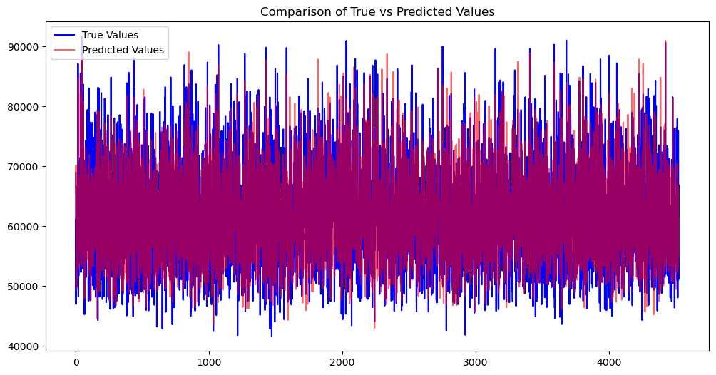

```
Mean Absolute Percentage Error: 0.07
```

```python
plt.figure(figsize=(12, 6))
plt.plot(y_test.to_numpy(), label='True Values', color='blue')
plt.plot(y_pred_list, label='Predicted Values', color='red', alpha=0.6)
plt.title("Comparison of True vs Predicted Values")
plt.legend()
plt.show()

# 평균 제곱 오차(MSE) 계산
mse = mean_absolute_percentage_error(y_test.to_numpy(), y_pred_list)
print(f"Mean Absolute Percentage Error: {mse:.2f}")
```

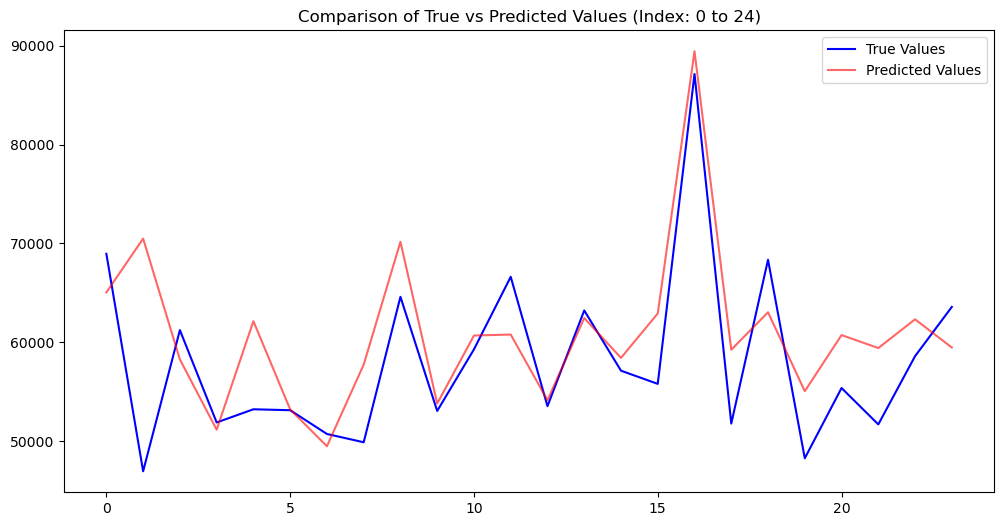

```python
def plot_predictions(y_true, y_pred, start_index, end_index):
    plt.figure(figsize=(12, 6))
    plt.plot(y_true[start_index:end_index], label='True Values', color='blue')
    plt.plot(y_pred[start_index:end_index], label='Predicted Values', color='red', alpha=0.6)
    plt.title(f"Comparison of True vs Predicted Values (Index: {start_index} to {end_index})")
    plt.legend()
    plt.show()

# 예시: 인덱스 100부터 200까지의 예측값과 실제값을 시각화
plot_predictions(y_test.to_numpy(), y_pred_list, 0, 24)
```

## 과거 데이터 생성

```python
def make_past_generation_input(data):
    data_column_name = ['generation(D-6)', 'generation(D-5)', 'generation(D-4)', 'generation(D-3)', 'generation(D-2)', 'generation(D-1)', 'generation(target)']

    for j in range(7):
        generation_data = data['Generation'].tolist()
        sliced_generation_data = generation_data[24+j*24:]
        empty_value_merging_data = sliced_generation_data + [NaN for i in range(24+j*24)]
        data[data_column_name[j]] = empty_value_merging_data

    nan_drop_data = data.dropna(axis=0)
    output_data = nan_drop_data.rename(columns={'Generation' : 'generation(D-7)', 'generation(target)':'generation'})

    return output_data

Gen_history_data = make_past_generation_input(data)
Gen_history_data
```

|  | Time | Daegu_Temp | Daegu_Precipitation | Daegu_Humidity | Daegu_Insolation | Daegu_Cloud | Daejeon_Temp | Daejeon_Precipitation | Daejeon_Humidity | Daejeon_Insolation | ... | Gwangju_Insolation | Gwangju_Cloud | generation(D-7) | generation(D-6) | generation(D-5) | generation(D-4) | generation(D-3) | generation(D-2) | generation(D-1) | generation |
| --- | --- | --- | --- | --- | --- | --- | --- | --- | --- | --- | --- | --- | --- | --- | --- | --- | --- | --- | --- | --- | --- |
| 0 | 2018-01-01 00:00:00 | 0.8 | 0.0 | 37.0 | 0.00 | 0 | -2.5 | 0.0 | 70.0 | 0.010 | ... | 0.06 | 7 | 62446 | 62145.0 | 70214.0 | 72583.0 | 72427.0 | 71501.0 | 67314.0 | 64300.0 |
| 1 | 2018-01-01 01:00:00 | 0.1 | 0.0 | 43.0 | 0.00 | 0 | -2.5 | 0.0 | 67.0 | 0.000 | ... | 0.06 | 6 | 59691 | 59313.0 | 66714.0 | 68811.0 | 68787.0 | 68204.0 | 64428.0 | 61264.0 |
| 2 | 2018-01-01 02:00:00 | 0.0 | 0.0 | 46.0 | 0.01 | 0 | -2.9 | 0.0 | 63.0 | 0.000 | ... | 0.06 | 4 | 57231 | 56977.0 | 64267.0 | 66239.0 | 66141.0 | 65618.0 | 61928.0 | 58716.0 |
| 3 | 2018-01-01 03:00:00 | -0.1 | 0.0 | 47.0 | 0.01 | 0 | -3.0 | 0.0 | 64.0 | 0.000 | ... | 0.06 | 3 | 55500 | 55828.0 | 62935.0 | 64792.0 | 64752.0 | 63970.0 | 60317.0 | 57332.0 |
| 4 | 2018-01-01 04:00:00 | -0.4 | 0.0 | 47.0 | 0.01 | 0 | -3.4 | 0.0 | 73.0 | 0.000 | ... | 0.06 | 3 | 54821 | 55675.0 | 62446.0 | 64326.0 | 64128.0 | 63422.0 | 59740.0 | 56844.0 |
| ... | ... | ... | ... | ... | ... | ... | ... | ... | ... | ... | ... | ... | ... | ... | ... | ... | ... | ... | ... | ... | ... |
| 22459 | 2020-07-24 19:00:00 | 21.0 | 1.9 | 94.0 | 0.17 | 10 | 23.0 | 0.1 | 92.0 | 0.390 | ... | 0.21 | 6 | 66648 | 59014.0 | 59536.0 | 70309.0 | 71398.0 | 71418.0 | 70630.0 | 70347.0 |
| 22460 | 2020-07-24 20:00:00 | 20.9 | 1.0 | 93.0 | 0.04 | 10 | 22.5 | 0.0 | 96.0 | 0.225 | ... | 0.06 | 10 | 65929 | 59582.0 | 60381.0 | 69399.0 | 70577.0 | 70952.0 | 70355.0 | 70092.0 |
| 22461 | 2020-07-24 21:00:00 | 20.8 | 0.4 | 95.0 | 0.04 | 10 | 21.8 | 0.0 | 96.0 | 0.060 | ... | 0.06 | 8 | 65152 | 59890.0 | 60578.0 | 67993.0 | 68939.0 | 69851.0 | 69357.0 | 69176.0 |
| 22462 | 2020-07-24 22:00:00 | 20.6 | 1.3 | 95.0 | 0.03 | 10 | 21.6 | 0.0 | 97.0 | 0.060 | ... | 0.06 | 8 | 62799 | 58264.0 | 58973.0 | 65288.0 | 66191.0 | 67102.0 | 66404.0 | 66569.0 |
| 22463 | 2020-07-24 23:00:00 | 20.5 | 2.0 | 95.0 | 0.03 | 10 | 21.6 | 0.0 | 97.0 | 0.050 | ... | 0.06 | 10 | 60246 | 56259.0 | 56818.0 | 62176.0 | 63173.0 | 63863.0 | 62895.0 | 63311.0 |

22464 rows × 39 columns

```python
features = Gen_history_data.drop(columns=["Time","Generation"])
target = Gen_history_data["Generation"]
X_train, X_test, y_train, y_test = train_test_split(features, target, test_size=0.2, random_state=42)

scaler = StandardScaler()
X_train = scaler.fit_transform(X_train)
X_test = scaler.transform(X_test)

train_dataset = TabularDataset(torch.FloatTensor(X_train), torch.FloatTensor(y_train.to_numpy()))
test_dataset = TabularDataset(torch.FloatTensor(X_test), torch.FloatTensor(y_test.to_numpy()))


train_loader = DataLoader(dataset=train_dataset, batch_size=64)
test_loader = DataLoader(dataset=test_dataset, batch_size=1)

model = NeuralNet(X_train.shape[1])
criterion = nn.MSELoss()
optimizer = optim.Adam(model.parameters(), lr=0.001)

epochs = 1000
for epoch in tqdm(range(epochs)):
    model.train()
    for X_batch, y_batch in train_loader:
        optimizer.zero_grad()
        y_pred = model(X_batch)
        loss = criterion(y_pred, y_batch.unsqueeze(1))
        loss.backward()
        optimizer.step()

model.eval()
y_pred_list = []
with torch.no_grad():
    for X_batch, _ in test_loader:
        y_pred = model(X_batch)
        y_pred_list.append(y_pred.cpu().numpy())

y_pred_list = [a.squeeze().tolist() for a in y_pred_list]
```

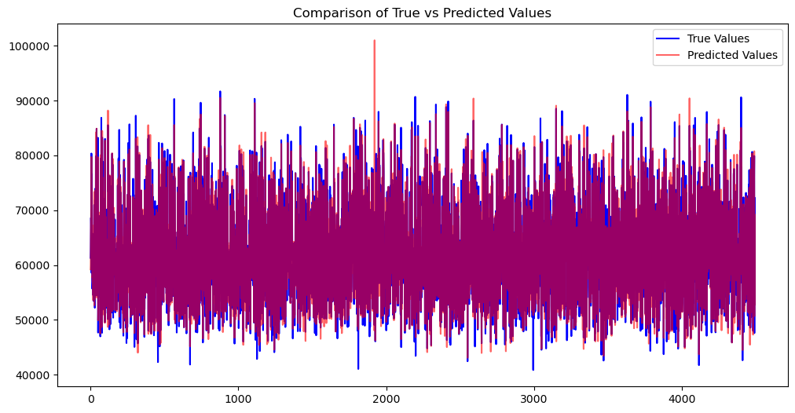

```
Mean Absolute Percentage Error: 0.02
```

```python
plt.figure(figsize=(12, 6))
plt.plot(y_test.to_numpy(), label='True Values', color='blue')
plt.plot(y_pred_list, label='Predicted Values', color='red', alpha=0.6)
plt.title("Comparison of True vs Predicted Values")
plt.legend()
plt.show()

# 평균 제곱 오차(MSE) 계산
mse = mean_absolute_percentage_error(y_test.to_numpy(), y_pred_list)
print(f"Mean Absolute Percentage Error: {mse:.2f}")
```

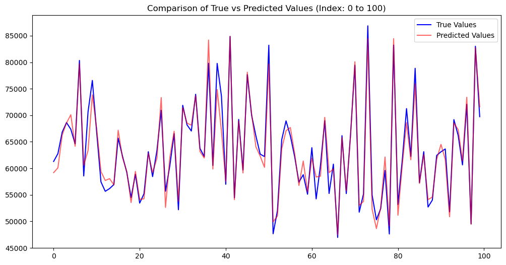

```python
def plot_predictions(y_true, y_pred, start_index, end_index):
    plt.figure(figsize=(12, 6))
    plt.plot(y_true[start_index:end_index], label='True Values', color='blue')
    plt.plot(y_pred[start_index:end_index], label='Predicted Values', color='red', alpha=0.6)
    plt.title(f"Comparison of True vs Predicted Values (Index: {start_index} to {end_index})")
    plt.legend()
    plt.show()

# 예시: 인덱스 100부터 200까지의 예측값과 실제값을 시각화
plot_predictions(y_test.to_numpy(), y_pred_list, 0, 100)
```

```python
model_scripted = torch.jit.script(model)
model_scripted.save('model_scripted.pt')
```

```python
Gen_history_data.to_csv('Gen_History_data.csv')
```